# (LetterBoxd Visualization)

## by (Faris AlShammari)

## Investigation Overview

#### The Visualizations interesed about movies and directors

## Dataset Overview

#### The dataset for the movie's likes, views and rates count and its average rate and released year.

## 1- Univariate Exploration

## 1.1- Average Rate

##### Movie's Rate is the most important thing that describe if the movie is good or bad and it gives a feedback for who want to watch the movie. And here the chart shows the average rate of the movies.

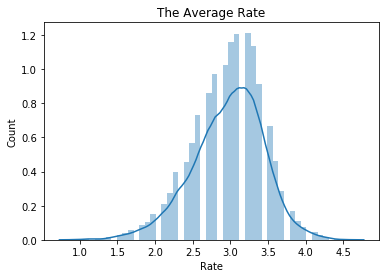

```python
sb.distplot(df_Movies['avg_rating'])
plt.xlabel('Rate')
plt.ylabel('Count')
plt.title('The Average Rate');
```

### The chart shows the average rate of movies. and when we looking at the chart we can noticed that the average rate is (3/5), and the most rates counts are between (3 to 3.5) out of (5).

## 1.2- Which genre is most popular

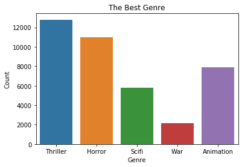

```python
List = ['Thriller','Horror','Scifi','War', 'Animation']
sb.countplot(data = df_Movies , x = 'genre', order = List);
plt.title('The Best Genre')
plt.xlabel('Genre')
plt.ylabel('Count');
```

### this chart shows that the "Thriller" is the most genre popular which contains arround (12,000) movies and the second is "Horror" movies which contains almost (11,000) movies, and the less popular is "War" movies with only (2,000) movies.

## 1.3- Directors popularity

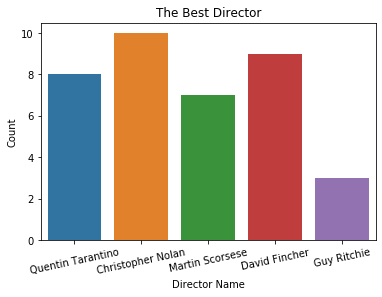

```python
Directors = ['Quentin Tarantino', 'Christopher Nolan', 'Martin Scorsese', 'David Fincher', 'Guy Ritchie']
sb.countplot(data = df_Movies , x = 'director', order = Directors);
plt.xticks(rotation = 12)
plt.title('The Best Director')
plt.xlabel('Director Name')
plt.ylabel('Count');
```

### We can noticed that "Christopher Nolan" has the most popular followed by "David Fincher" then "Quentin Tarantino" and "Guy Ritchie" has the lowest popularity.

## 2- Bivariate Exploration

## 2.1- Relation between Average rate and running time

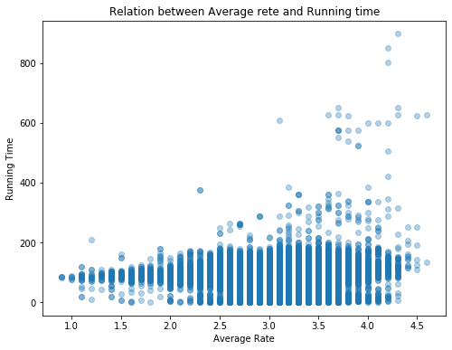

```python
plt.figure(figsize = [8, 6])
plt.subplot(1, 1, 1)
sb.regplot(data = df_Movies, x = 'avg_rating', y = 'running_time', fit_reg = False,scatter_kws = {'alpha' : 1/3})
plt.title('Relation between Average rete and Running time')
plt.xlabel('Average Rate')
plt.ylabel('Running Time');
```

### The observation is the running time have a positive affected on the Average rate

## 2.2- Comparison between the Views by the years

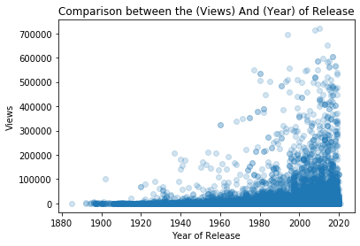

```python
plt.scatter(data = df_Movies, x = 'year', y = 'views', alpha = 1/5);
plt.title('Comparison between the (Views) And (Year) of Release');
plt.xlabel('Year of Release');
plt.ylabel('Views');
```

### the relation betweet the two vairable which are (Year, views) so last decade is the highest views, And early 90's there were not that much of views. And in 1960 has an extreme values which means in this year has a good movies that deserve to watch.